# Setup

#### Self-Efficacy

I first compare likes and likes plus dislikes to the control condition.

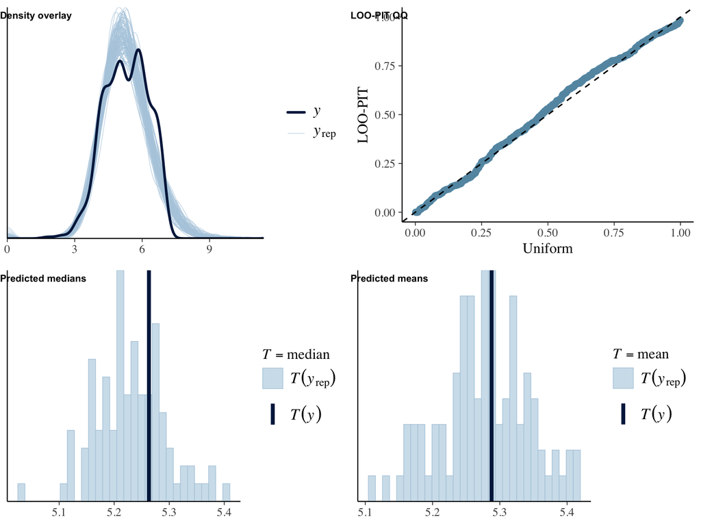

```
 Family: hurdle_gamma
  Links: mu = log; hu = logit
Formula: self_eff_fs ~ 1 + age + male + edu + version
         hu ~ 1 + age + male + edu + version
   Data: object (Number of observations: 558)
  Draws: 4 chains, each with iter = 1000; warmup = 500; thin = 1;
         total post-warmup draws = 2000

Regression Coefficients:
                       Estimate Est.Error l-95% CI u-95% CI Rhat Bulk_ESS Tail_ESS
Intercept                  1.62      0.04     1.56     1.69 1.00     2059     1818
hu_Intercept              -9.67      5.96   -22.68     0.77 1.00     1083      935
age                       -0.00      0.00    -0.00     0.00 1.00     1870     1308
male                       0.02      0.02    -0.02     0.05 1.00     2030     1365
edu                        0.03      0.01     0.01     0.04 1.00     3052     1364
versionLike               -0.02      0.02    -0.05     0.02 1.00     1234     1711
versionLike&dislike       -0.02      0.02    -0.06     0.02 1.00     1225     1593
hu_age                     0.00      0.08    -0.16     0.17 1.00     1301      980
hu_male                   -0.20      2.86    -6.16     5.63 1.00     1545     1177
hu_edu                    -0.19      1.67    -3.65     3.18 1.00     1529      991
hu_versionLike            -0.18      4.28   -10.19     8.54 1.00      929      713
hu_versionLike&dislike    -0.34      4.43    -9.95     8.63 1.01      806      604

Further Distributional Parameters:
      Estimate Est.Error l-95% CI u-95% CI Rhat Bulk_ESS Tail_ESS
shape    27.84      1.66    24.56    31.00 1.00     1615     1380

Draws were sampled using sampling(NUTS). For each parameter, Bulk_ESS
and Tail_ESS are effective sample size measures, and Rhat is the potential
scale reduction factor on split chains (at convergence, Rhat = 1).
```

```
Results of marginal effects:
      Outcome    term                 contrast estimate conf.low conf.high
1 self_eff_fs     age                    dY/dX -0.00016 -0.00609   0.00586
2 self_eff_fs     edu                    dY/dX  0.13385  0.02102   0.24465
3 self_eff_fs    male                    1 - 0  0.07919 -0.10022   0.27798
4 self_eff_fs version Like & dislike - Control -0.09072 -0.30609   0.12492
5 self_eff_fs version           Like - Control -0.09061 -0.29045   0.10711
```

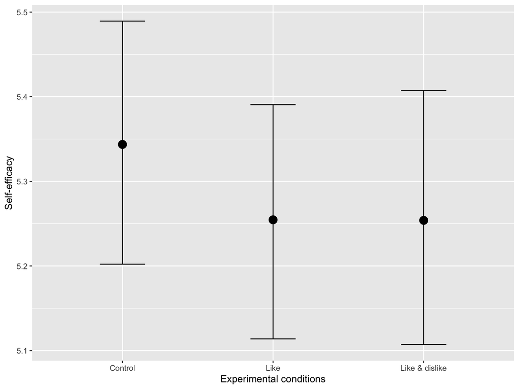

```r
run_hurdles(
  object = d,
  name = "selfeff_ctrl",
  outcome = "self_eff_fs",
  predictor = "version",
  y_lab = "Self-efficacy",
  x_lab = "Experimental conditions"
  )
```

I then compare the likes and control conditions to the likes plus dislikes condition.

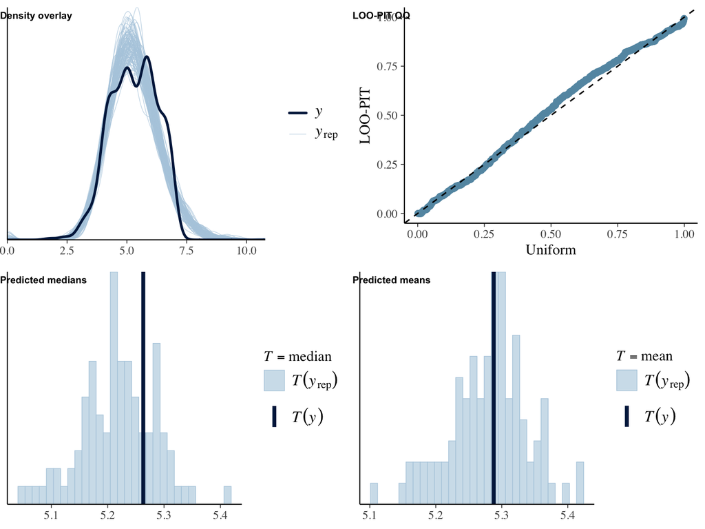

```
 Family: hurdle_gamma
  Links: mu = log; hu = logit
Formula: self_eff_fs ~ 1 + age + male + edu + version_lkdslk
         hu ~ 1 + age + male + edu + version_lkdslk
   Data: object (Number of observations: 558)
  Draws: 4 chains, each with iter = 1000; warmup = 500; thin = 1;
         total post-warmup draws = 2000

Regression Coefficients:
                         Estimate Est.Error l-95% CI u-95% CI Rhat Bulk_ESS Tail_ESS
Intercept                    1.61      0.03     1.54     1.67 1.00     2352     1525
hu_Intercept                -9.94      5.86   -22.60    -0.03 1.00     1277     1089
age                         -0.00      0.00    -0.00     0.00 1.00     2149     1359
male                         0.02      0.02    -0.02     0.05 1.00     2348     1070
edu                          0.02      0.01     0.01     0.04 1.00     2527     1447
version_lkdslkLike           0.00      0.02    -0.04     0.04 1.00     1901     1791
version_lkdslkControl        0.02      0.02    -0.02     0.06 1.00     1924     1421
hu_age                       0.00      0.08    -0.16     0.17 1.00     1497     1060
hu_male                     -0.21      3.20    -7.14     5.90 1.01     1669      993
hu_edu                      -0.22      1.76    -4.06     3.03 1.00     1140      802
hu_version_lkdslkLike        0.17      4.44    -8.55     9.56 1.00      823      955
hu_version_lkdslkControl     0.10      4.49    -9.42     9.22 1.00      919      841

Further Distributional Parameters:
      Estimate Est.Error l-95% CI u-95% CI Rhat Bulk_ESS Tail_ESS
shape    27.90      1.70    24.72    31.48 1.00     2128     1111

Draws were sampled using sampling(NUTS). For each parameter, Bulk_ESS
and Tail_ESS are effective sample size measures, and Rhat is the potential
scale reduction factor on split chains (at convergence, Rhat = 1).
```

```
Results of marginal effects:
      Outcome           term                 contrast  estimate conf.low conf.high
1 self_eff_fs            age                    dY/dX -5.51e-05 -0.00567   0.00544
2 self_eff_fs            edu                    dY/dX  1.33e-01  0.01935   0.24421
3 self_eff_fs           male                    1 - 0  8.22e-02 -0.08686   0.24891
4 self_eff_fs version_lkdslk Control - Like & dislike  9.15e-02 -0.12557   0.31363
5 self_eff_fs version_lkdslk    Like - Like & dislike -2.04e-04 -0.20033   0.21861
```

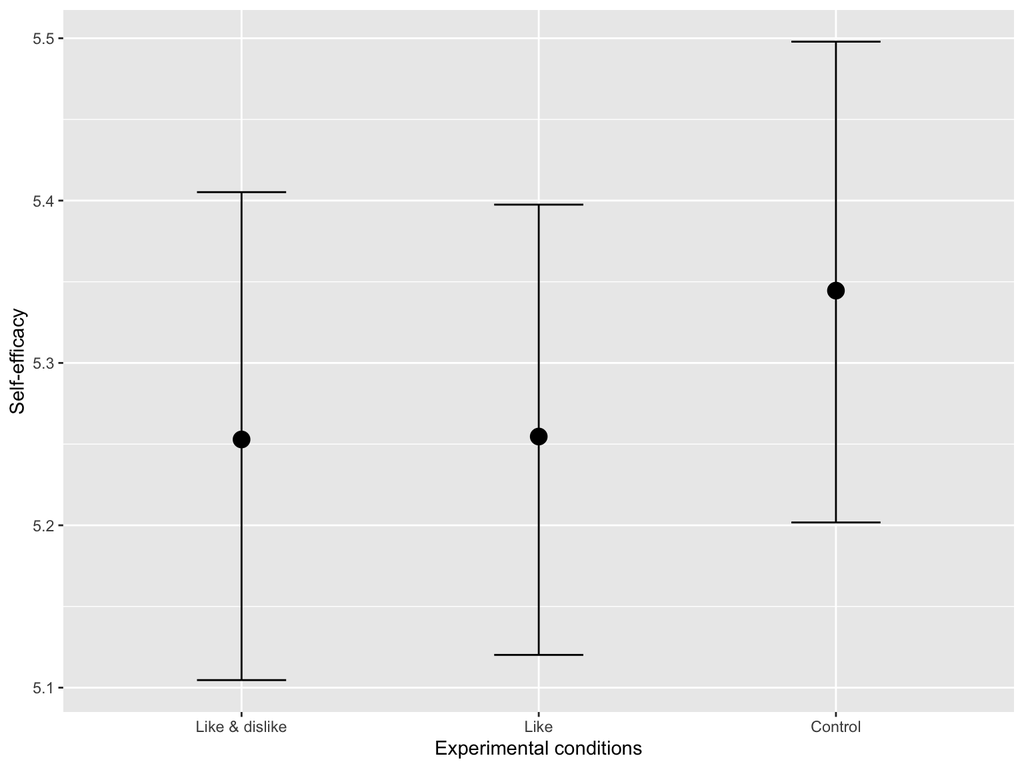

```r
run_hurdles(
  object = d,
  name = "selfeff_lkdslk",
  outcome = "self_eff_fs",
  predictor = "version_lkdslk",
  y_lab = "Self-efficacy",
  x_lab = "Experimental conditions"
  )
```

### Words

#### Privacy Concerns

```
Some PIT values larger than 1! Largest:  1
Rounding PIT > 1 to 1.
```

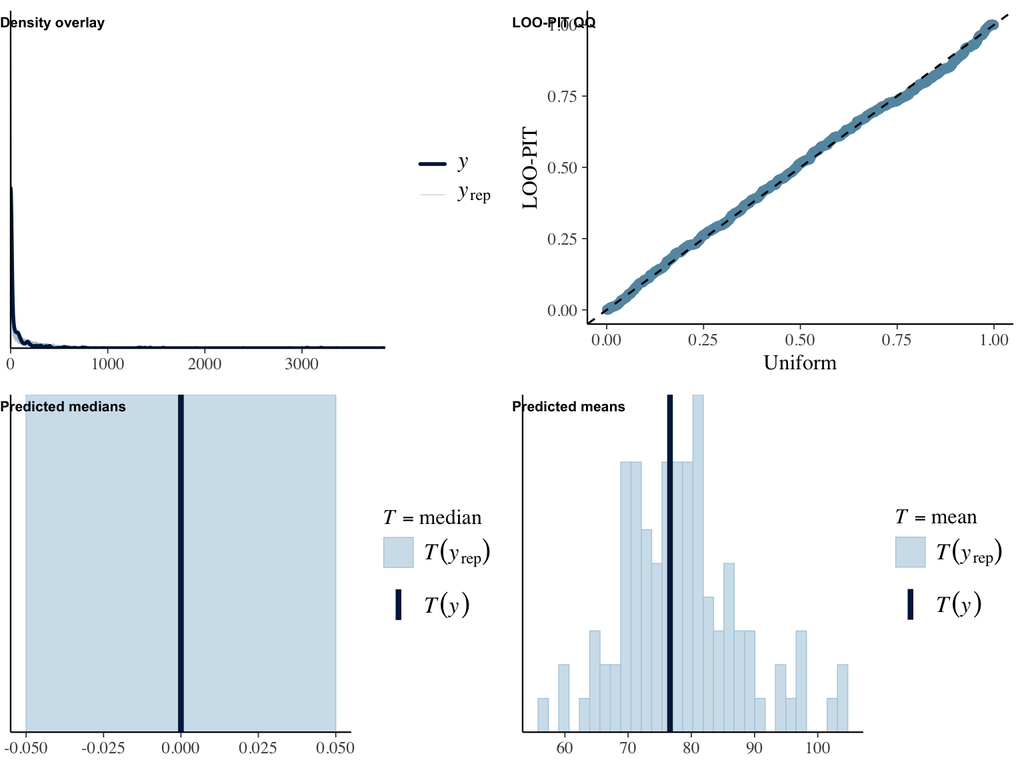

```
 Family: hurdle_gamma
  Links: mu = log; hu = logit
Formula: words ~ 1 + age + male + edu + pri_con_fs
         hu ~ 1 + age + male + edu + pri_con_fs
   Data: object (Number of observations: 558)
  Draws: 4 chains, each with iter = 1000; warmup = 500; thin = 1;
         total post-warmup draws = 2000

Regression Coefficients:
              Estimate Est.Error l-95% CI u-95% CI Rhat Bulk_ESS Tail_ESS
Intercept         5.65      0.41     4.86     6.45 1.00     3240     1739
hu_Intercept      0.53      0.40    -0.22     1.35 1.00     4327     1511
age              -0.00      0.01    -0.01     0.01 1.00     3994     1771
male             -0.08      0.16    -0.40     0.23 1.00     3417     1478
edu              -0.01      0.10    -0.20     0.18 1.00     3116     1505
pri_con_fs       -0.10      0.05    -0.20     0.01 1.00     3745     1606
hu_age           -0.01      0.01    -0.02     0.00 1.00     5076     1459
hu_male          -0.03      0.18    -0.41     0.31 1.00     3527     1495
hu_edu           -0.23      0.10    -0.43    -0.03 1.00     3657     1481
hu_pri_con_fs     0.19      0.06     0.08     0.30 1.01     4038     1521

Further Distributional Parameters:
      Estimate Est.Error l-95% CI u-95% CI Rhat Bulk_ESS Tail_ESS
shape     0.69      0.06     0.59     0.81 1.00     5112     1668

Draws were sampled using sampling(NUTS). For each parameter, Bulk_ESS
and Tail_ESS are effective sample size measures, and Rhat is the potential
scale reduction factor on split chains (at convergence, Rhat = 1).
```

```
Results of marginal effects:
  Outcome       term contrast estimate conf.low conf.high
1   words        age    dY/dX    0.196   -0.868      1.18
2   words        edu    dY/dX    9.037   -8.853     26.57
3   words       male    1 - 0   -4.560  -34.890     24.71
4   words pri_con_fs    dY/dX  -15.758  -26.343     -6.10
```

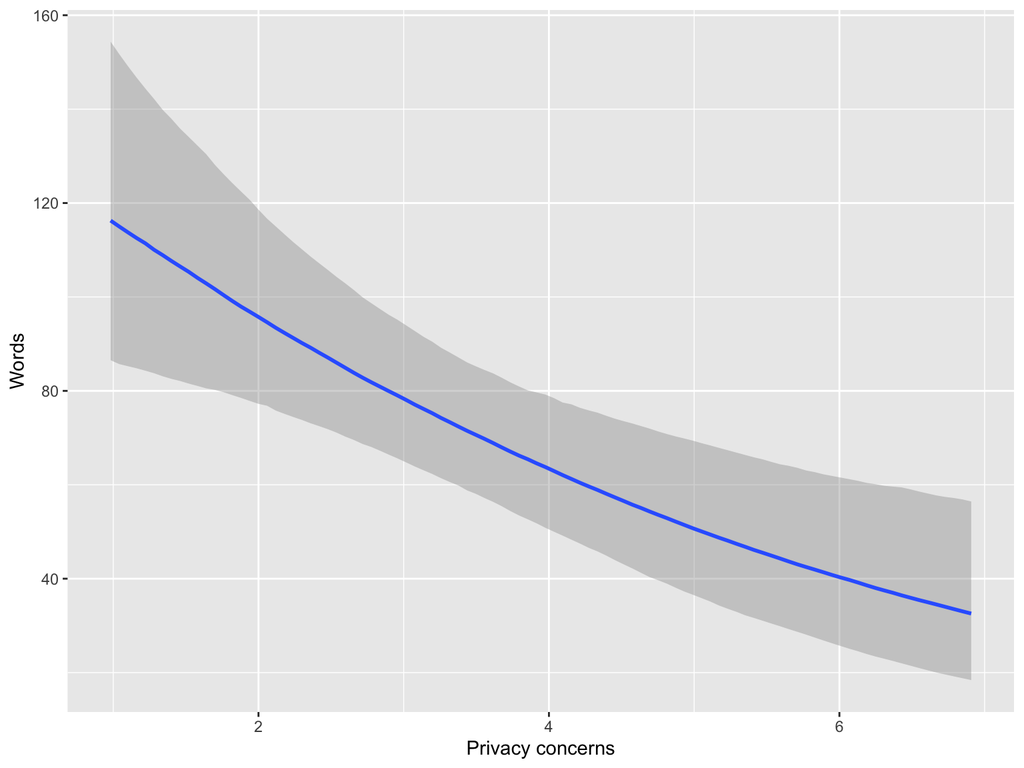

```r
run_hurdles(
  object = d,
  name = "wrds_pricon",
  outcome = "words",
  predictor = "pri_con_fs",
  y_lab = "Words",
  x_lab = "Privacy concerns"
  )
```

Let’s explore how number of communicated words differ for people very much concerned versus not concerned at all.

```r
# let's extract effects for 1
wrds_pricon_1 <-
  fig_wrds_pricon$data %>%
  filter(pri_con_fs == min(pri_con_fs)) %>%
  pull(estimate__) %>%
  round(0)

# let's extract effects for 7
wrds_pricon_7 <-
  fig_wrds_pricon$data %>%
  filter(pri_con_fs == max(pri_con_fs)) %>%
  pull(estimate__) %>%
  round(0)
```

People who were not concerned at all communicated on average 116 words, whereas people strongly concerned communicated on average 33 words.

#### Gratifications General

```
Some PIT values larger than 1! Largest:  1
Rounding PIT > 1 to 1.
```

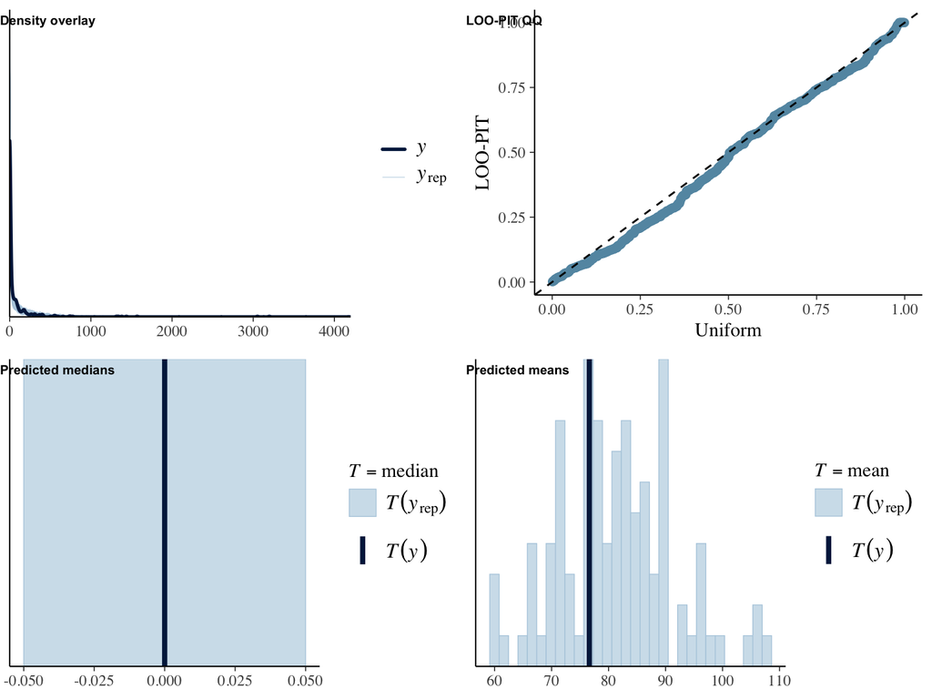

```
 Family: hurdle_gamma
  Links: mu = log; hu = logit
Formula: words ~ 1 + age + male + edu + grats_gen_fs
         hu ~ 1 + age + male + edu + grats_gen_fs
   Data: object (Number of observations: 558)
  Draws: 4 chains, each with iter = 1000; warmup = 500; thin = 1;
         total post-warmup draws = 2000

Regression Coefficients:
                Estimate Est.Error l-95% CI u-95% CI Rhat Bulk_ESS Tail_ESS
Intercept           4.29      0.49     3.36     5.25 1.00     3639     1595
hu_Intercept        2.27      0.53     1.25     3.30 1.00     4092     1709
age                -0.00      0.01    -0.02     0.01 1.00     4465     1810
male               -0.08      0.16    -0.39     0.23 1.00     3517     1479
edu                 0.04      0.09    -0.15     0.22 1.00     3623     1509
grats_gen_fs        0.22      0.07     0.07     0.36 1.00     4374     1469
hu_age             -0.01      0.01    -0.02     0.00 1.00     4315     1574
hu_male            -0.08      0.18    -0.44     0.27 1.00     3474     1385
hu_edu             -0.22      0.11    -0.44     0.00 1.00     4513     1400
hu_grats_gen_fs    -0.23      0.08    -0.38    -0.07 1.00     3970     1570

Further Distributional Parameters:
      Estimate Est.Error l-95% CI u-95% CI Rhat Bulk_ESS Tail_ESS
shape     0.70      0.06     0.61     0.81 1.00     4221     1771

Draws were sampled using sampling(NUTS). For each parameter, Bulk_ESS
and Tail_ESS are effective sample size measures, and Rhat is the potential
scale reduction factor on split chains (at convergence, Rhat = 1).
```

```
Results of marginal effects:
  Outcome         term contrast estimate conf.low conf.high
1   words          age    dY/dX   0.0661   -0.981       1.1
2   words          edu    dY/dX  12.1370   -4.361      29.9
3   words grats_gen_fs    dY/dX  26.5913   12.687      43.5
4   words         male    1 - 0  -2.7122  -31.964      24.4
```

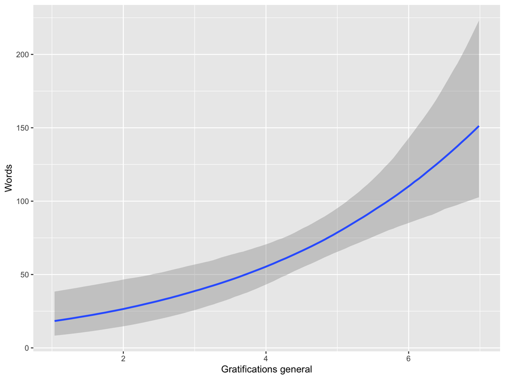

```r
run_hurdles(
  object = d,
  name = "wrds_grats",
  outcome = "words",
  predictor = "grats_gen_fs",
  y_lab = "Words",
  x_lab = "Gratifications general"
  )
```

#### Privacy Deliberation

```
Some PIT values larger than 1! Largest:  1
Rounding PIT > 1 to 1.
```

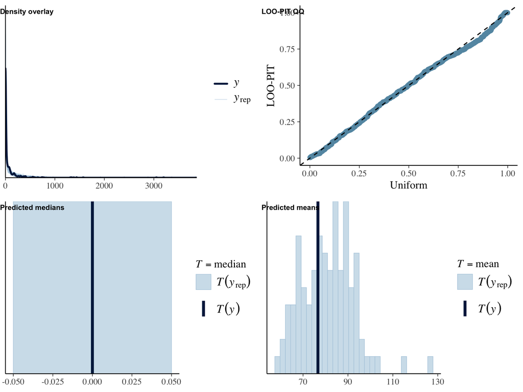

```
 Family: hurdle_gamma
  Links: mu = log; hu = logit
Formula: words ~ 1 + age + male + edu + pri_del_fs
         hu ~ 1 + age + male + edu + pri_del_fs
   Data: object (Number of observations: 558)
  Draws: 4 chains, each with iter = 1000; warmup = 500; thin = 1;
         total post-warmup draws = 2000

Regression Coefficients:
              Estimate Est.Error l-95% CI u-95% CI Rhat Bulk_ESS Tail_ESS
Intercept         6.51      0.51     5.50     7.51 1.01     3498     1597
hu_Intercept     -0.16      0.52    -1.14     0.82 1.00     4287     1570
age              -0.01      0.01    -0.02     0.01 1.00     3443     1600
male             -0.08      0.16    -0.39     0.23 1.00     3272     1458
edu              -0.02      0.09    -0.20     0.17 1.00     3386     1694
pri_del_fs       -0.27      0.07    -0.41    -0.13 1.01     3140     1341
hu_age           -0.01      0.01    -0.02     0.00 1.00     4333     1648
hu_male          -0.01      0.18    -0.36     0.34 1.00     2621     1506
hu_edu           -0.22      0.10    -0.42    -0.02 1.00     4281     1645
hu_pri_del_fs     0.30      0.08     0.15     0.46 1.00     3520     1706

Further Distributional Parameters:
      Estimate Est.Error l-95% CI u-95% CI Rhat Bulk_ESS Tail_ESS
shape     0.71      0.06     0.60     0.82 1.00     3537     1684

Draws were sampled using sampling(NUTS). For each parameter, Bulk_ESS
and Tail_ESS are effective sample size measures, and Rhat is the potential
scale reduction factor on split chains (at convergence, Rhat = 1).
```

```
Results of marginal effects:
  Outcome       term contrast estimate conf.low conf.high
1   words        age    dY/dX   -0.164    -1.27     0.891
2   words        edu    dY/dX    7.299   -10.29    25.460
3   words       male    1 - 0   -5.645   -33.67    22.932
4   words pri_del_fs    dY/dX  -33.189   -52.07   -20.147
```

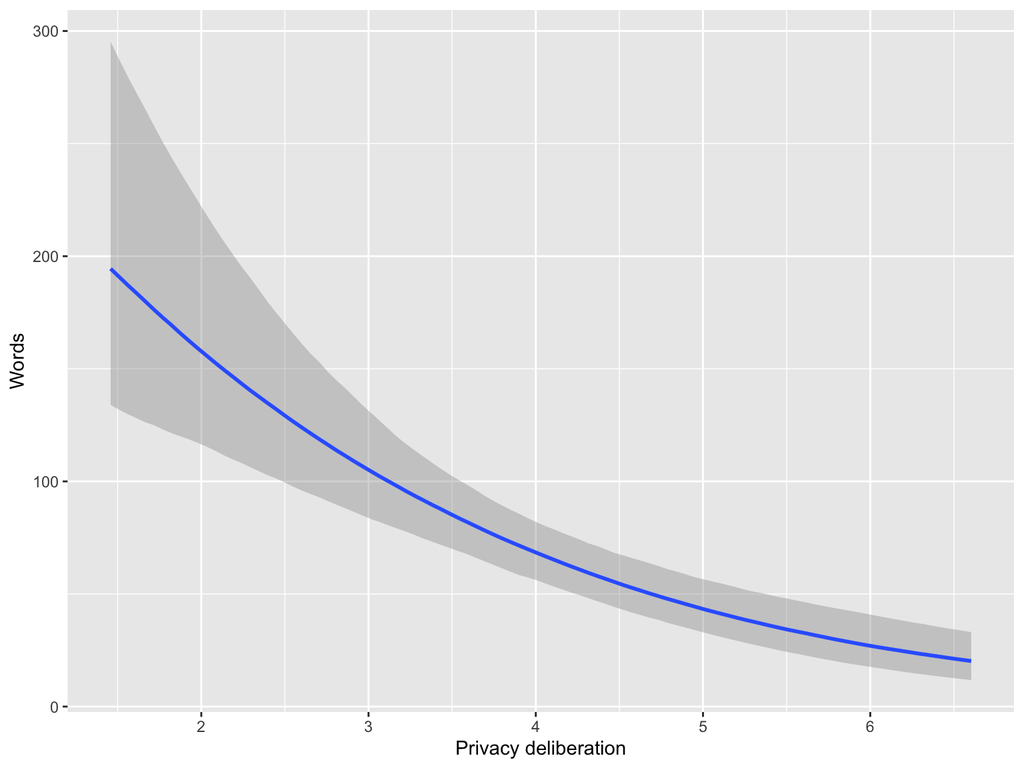

```r
run_hurdles(
  object = d,
  name = "wrds_pridel",
  outcome = "words",
  predictor = "pri_del_fs",
  y_lab = "Words",
  x_lab = "Privacy deliberation"
  )
```

#### Trust General

```
Some PIT values larger than 1! Largest:  1
Rounding PIT > 1 to 1.
```

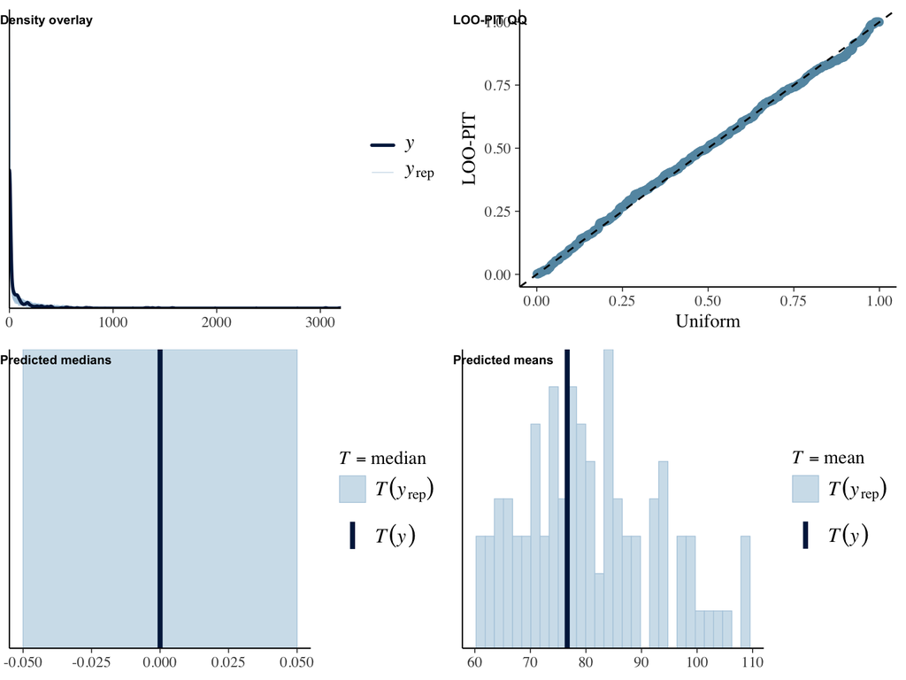

```
 Family: hurdle_gamma
  Links: mu = log; hu = logit
Formula: words ~ 1 + age + male + edu + trust_gen_fs
         hu ~ 1 + age + male + edu + trust_gen_fs
   Data: object (Number of observations: 558)
  Draws: 4 chains, each with iter = 1000; warmup = 500; thin = 1;
         total post-warmup draws = 2000

Regression Coefficients:
                Estimate Est.Error l-95% CI u-95% CI Rhat Bulk_ESS Tail_ESS
Intercept           4.24      0.58     3.11     5.36 1.00     3174     1592
hu_Intercept        3.11      0.64     1.86     4.36 1.00     4528     1462
age                -0.00      0.01    -0.01     0.01 1.00     4088     1701
male               -0.07      0.16    -0.40     0.25 1.00     3601     1415
edu                -0.01      0.09    -0.20     0.18 1.00     3933     1619
trust_gen_fs        0.21      0.10     0.02     0.39 1.00     3153     1714
hu_age             -0.01      0.01    -0.02     0.00 1.00     3722     1334
hu_male            -0.07      0.18    -0.41     0.29 1.00     3537     1606
hu_edu             -0.21      0.11    -0.43    -0.01 1.00     3852     1386
hu_trust_gen_fs    -0.36      0.10    -0.56    -0.17 1.00     4137     1399

Further Distributional Parameters:
      Estimate Est.Error l-95% CI u-95% CI Rhat Bulk_ESS Tail_ESS
shape     0.69      0.05     0.59     0.80 1.00     3598     1689

Draws were sampled using sampling(NUTS). For each parameter, Bulk_ESS
and Tail_ESS are effective sample size measures, and Rhat is the potential
scale reduction factor on split chains (at convergence, Rhat = 1).
```

```
Results of marginal effects:
  Outcome         term contrast estimate conf.low conf.high
1   words          age    dY/dX    0.274    -0.78      1.29
2   words          edu    dY/dX    8.102    -8.48     25.44
3   words         male    1 - 0   -3.033   -31.78     27.39
4   words trust_gen_fs    dY/dX   31.572    15.00     52.92
```

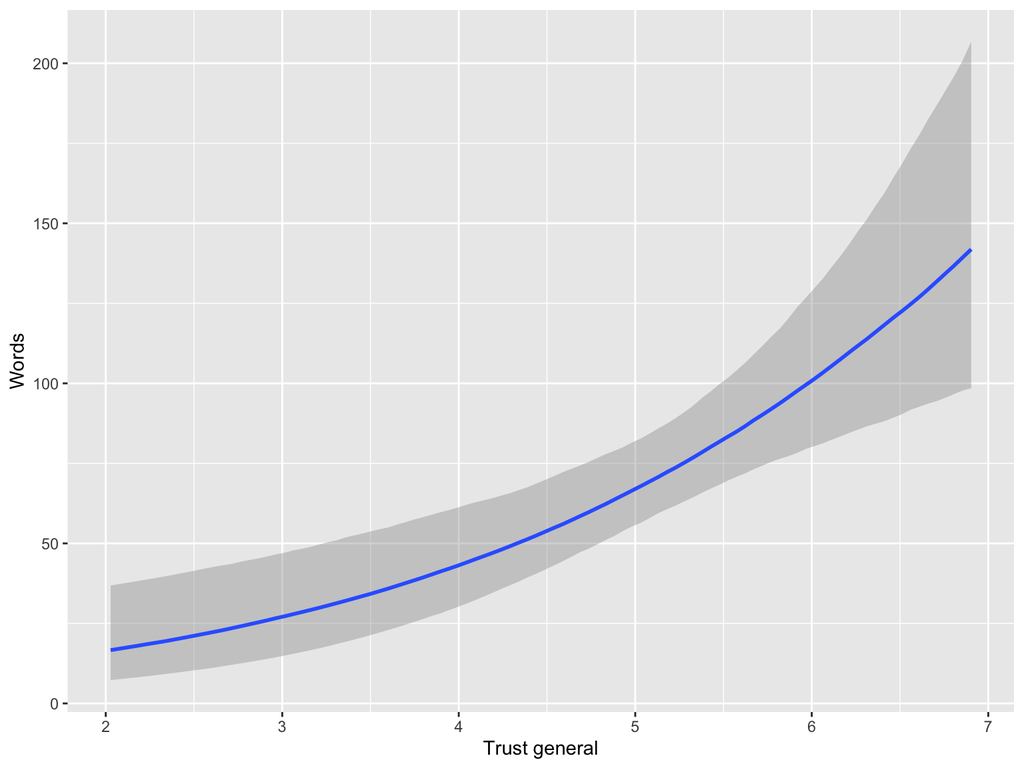

```r
run_hurdles(
  object = d,
  name = "wrds_trust",
  outcome = "words",
  predictor = "trust_gen_fs",
  y_lab = "Words",
  x_lab = "Trust general"
  )
```

#### Self-Efficacy

```
Some PIT values larger than 1! Largest:  1
Rounding PIT > 1 to 1.
```

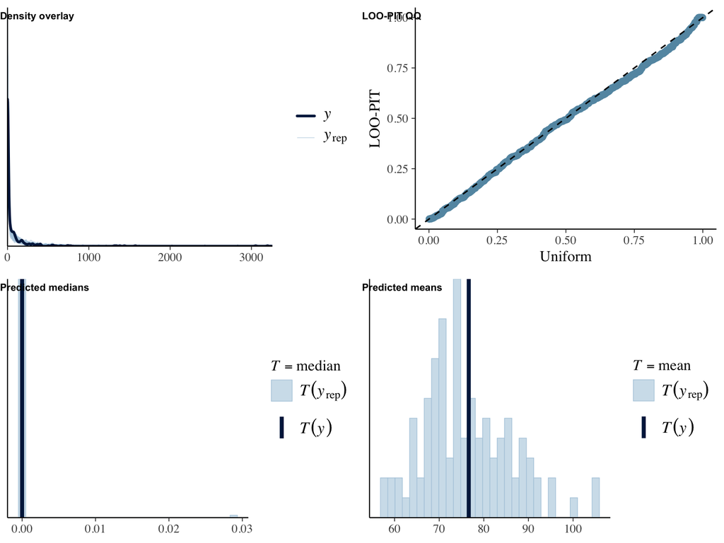

```
 Family: hurdle_gamma
  Links: mu = log; hu = logit
Formula: words ~ 1 + age + male + edu + self_eff_fs
         hu ~ 1 + age + male + edu + self_eff_fs
   Data: object (Number of observations: 558)
  Draws: 4 chains, each with iter = 1000; warmup = 500; thin = 1;
         total post-warmup draws = 2000

Regression Coefficients:
               Estimate Est.Error l-95% CI u-95% CI Rhat Bulk_ESS Tail_ESS
Intercept          2.19      0.48     1.24     3.15 1.00     3079     1776
hu_Intercept       5.79      0.70     4.44     7.22 1.00     3796     1671
age               -0.00      0.01    -0.01     0.01 1.00     3931     1683
male              -0.16      0.15    -0.44     0.14 1.01     3766     1403
edu               -0.07      0.09    -0.23     0.11 1.00     4328     1727
self_eff_fs        0.58      0.08     0.42     0.72 1.01     2505     1662
hu_age            -0.01      0.01    -0.02     0.00 1.00     3758     1461
hu_male           -0.01      0.18    -0.36     0.36 1.00     4027     1603
hu_edu            -0.12      0.11    -0.34     0.08 1.00     3786     1841
hu_self_eff_fs    -0.88      0.11    -1.09    -0.68 1.01     3796     1727

Further Distributional Parameters:
      Estimate Est.Error l-95% CI u-95% CI Rhat Bulk_ESS Tail_ESS
shape     0.80      0.07     0.67     0.93 1.00     4265     1445

Draws were sampled using sampling(NUTS). For each parameter, Bulk_ESS
and Tail_ESS are effective sample size measures, and Rhat is the potential
scale reduction factor on split chains (at convergence, Rhat = 1).
```

```
Results of marginal effects:
  Outcome        term contrast estimate conf.low conf.high
1   words         age    dY/dX   0.0449   -0.882     0.935
2   words         edu    dY/dX  -0.9637  -16.484    13.676
3   words        male    1 - 0 -11.8369  -37.713    14.530
4   words self_eff_fs    dY/dX  72.0557   55.471    95.556
```

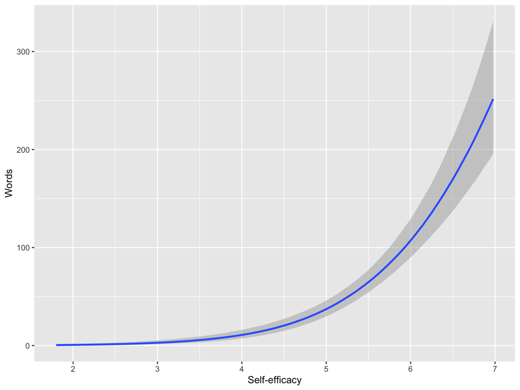

```r
run_hurdles(
  object = d,
  name = "wrds_selfeff",
  outcome = "words",
  predictor = "self_eff_fs",
  y_lab = "Words",
  x_lab = "Self-efficacy"
  )
```

The effects is markedly exponential. Let’s inspect the changes across values in self-efficacy.

```r
effects_wrds_selfeff <-
  slopes(
    fit_wrds_selfeff,
    newdata = datagrid(
      self_eff_fs = c(1, 6, 7)
      ),
   grid_type = "counterfactual"
    ) %>%
  filter(
    term == "self_eff_fs"
    ) %T>%
  print()
```

```
 self_eff_fs Estimate    2.5 %  97.5 %
           1    0.257   0.0902   0.693
           6  110.512  80.7501 154.923
           7  216.426 139.7475 344.625

Term: self_eff_fs
Type: response
Comparison: dY/dX
```

```r
# let's extract effects for 1
effects_wrds_selfeff_12 <-
  effects_wrds_selfeff %>%
  filter(
    self_eff_fs == 1 &
      term == "self_eff_fs") %>%
  select(estimate)

# let's extract effects for 7
effects_wrds_selfeff_67 <-
  effects_wrds_selfeff %>%
  filter(
    self_eff_fs == 6 &
      term == "self_eff_fs") %>%
  select(estimate)
```

Whereas a change in self-efficacy from 1 to 2 led to an increase of 0 words, a change from 6 to 7 led to an increase of 111 words.

Let’s explore how number of communicated words differ for people very much self-efficacious versus not self-efficacious at all.

```r
# let's extract effects for 1
wrds_selfeff_1 <-
  fig_wrds_selfeff$data %>%
  filter(self_eff_fs == min(self_eff_fs)) %>%
  pull(estimate__) %>%
  round(0)

# let's extract effects for 7
wrds_selfeff_7 <-
  fig_wrds_selfeff$data %>%
  filter(self_eff_fs == max(self_eff_fs)) %>%
  pull(estimate__) %>%
  round(0)
```

People who reported no self-efficacy at all communicated on average 1 words, whereas people with very high self-efficacy communicated on average 252 words.

## Visualization

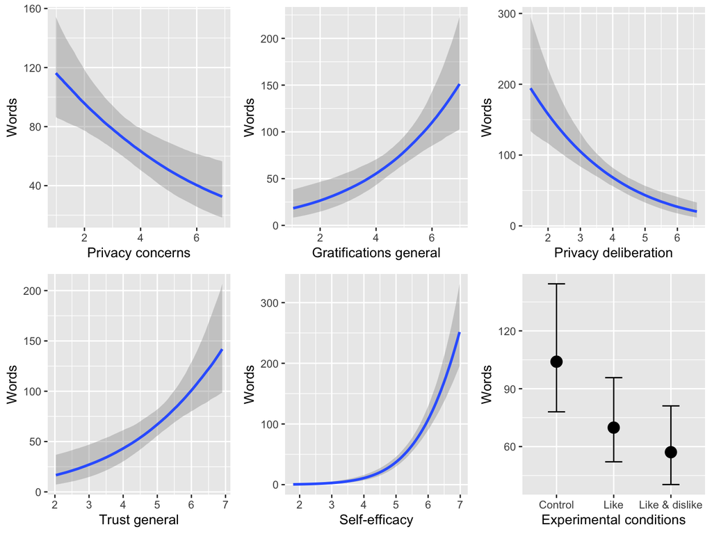

```r
fig_results <-
  plot_grid(
    fig_wrds_pricon,
    fig_wrds_grats,
    fig_wrds_pridel,
    fig_wrds_trust,
    fig_wrds_selfeff,
    fig_wrds_ctrl
    ) %T>%
  print()
```

```r
# Save visualizations
ggsave("figures/results/effects.pdf")
ggsave("figures/results/effects.png")
```

## Table

Make table of slopes

```r
tab_slopes <-
  rbind(
    slopes_wrds_pricon,
    slopes_wrds_grats,
    slopes_wrds_pridel,
    slopes_wrds_trust,
    slopes_wrds_selfeff,
    slopes_wrds_ctrl,
    slopes_wrds_lkdslk,
    slopes_pricon_ctrl,
    slopes_pricon_lkdslk,
    slopes_grats_ctrl,
    slopes_grats_lkdslk,
    slopes_pridel_ctrl,
    slopes_pridel_lkdslk,
    slopes_trust_ctrl,
    slopes_trust_lkdslk,
    slopes_selfeff_ctrl,
    slopes_selfeff_lkdslk
    ) %>%
  as.data.frame() %>%
  mutate(
    term = ifelse(
      .$contrast == "Like - Control",
      "Like - Control",
      ifelse(
        .$contrast == "Like & dislike - Control",
        "Like & dislike - Control",
        ifelse(
          .$contrast == "Like - Like & dislike",
          "Like - Like & dislike",
          .$term
          )
        )
      ),
    Predictor = recode(
      term,
      "Like - Control" = "Like vs. control",
      "Like & dislike - Control" = "Like & dislike vs. control",
      "Like - Like & dislike" = "Like vs. like & dislike",
      "pri_con_fs" = "Privacy concerns",
      "pri_del_fs" = "Privacy deliberation",
      "grats_gen_fs" = "Expected gratifications",
      "trust_gen_fs" = "Trust",
      "self_eff_fs" = "Self-efficacy"
    ),
    Outcome = recode(
      Outcome,
      "pri_con_fs" = "Privacy concerns",
      "pri_del_fs" = "Privacy deliberation",
      "grats_gen_fs" = "Expected gratifications",
      "trust_gen_fs" = "Trust",
      "self_eff_fs" = "Self-efficacy"
    )
  ) %>%
  filter(
    Predictor %in% c(
      "Like vs. control",
      "Like & dislike vs. control",
      "Like vs. like & dislike",
      "Privacy concerns",
      "Privacy deliberation",
      "Expected gratifications",
      "Trust",
      "Self-efficacy")
  ) %>%
  mutate(
    Predictor = factor(Predictor, levels = c(
      "Self-efficacy",
      "Trust",
      "Privacy deliberation",
      "Expected gratifications",
      "Privacy concerns",
      "Like vs. like & dislike",
      "Like & dislike vs. control",
      "Like vs. control"
      )
    ),
    Estimate =
      ifelse(
        Outcome == "words",
        round(estimate),
        estimate
      ),
    LL =
      ifelse(
        Outcome == "words",
        round(conf.low),
        conf.low
      ),
    UL =
      ifelse(
        Outcome == "words",
        round(conf.high),
        conf.high
      ),
  ) %>%
  select(
    Outcome,
    Predictor,
    Estimate,
    LL,
    UL
    )

tab_slopes %>%
  kable() %>%
  kable_styling("striped") %>%
  scroll_box(width = "100%")
```

| Outcome | Predictor | Estimate | LL | UL |
| --- | --- | --- | --- | --- |
| words | Privacy concerns | -16.000 | -26.000 | -6.000 |
| words | Expected gratifications | 27.000 | 13.000 | 44.000 |
| words | Privacy deliberation | -33.000 | -52.000 | -20.000 |
| words | Trust | 32.000 | 15.000 | 53.000 |
| words | Self-efficacy | 72.000 | 55.000 | 96.000 |
| words | Like & dislike vs. control | -47.000 | -94.000 | -11.000 |
| words | Like vs. control | -35.000 | -77.000 | 2.000 |
| words | Like vs. like & dislike | 13.000 | -20.000 | 45.000 |
| Privacy concerns | Like & dislike vs. control | 0.184 | -0.128 | 0.500 |
| Privacy concerns | Like vs. control | 0.042 | -0.260 | 0.358 |
| Privacy concerns | Like vs. like & dislike | -0.145 | -0.484 | 0.195 |
| Expected gratifications | Like & dislike vs. control | -0.201 | -0.482 | 0.056 |
| Expected gratifications | Like vs. control | -0.172 | -0.420 | 0.089 |
| Expected gratifications | Like vs. like & dislike | 0.035 | -0.230 | 0.303 |
| Privacy deliberation | Like & dislike vs. control | -0.040 | -0.294 | 0.189 |
| Privacy deliberation | Like vs. control | -0.004 | -0.243 | 0.232 |
| Privacy deliberation | Like vs. like & dislike | 0.038 | -0.205 | 0.272 |
| Trust | Like & dislike vs. control | -0.129 | -0.335 | 0.077 |
| Trust | Like vs. control | -0.149 | -0.351 | 0.047 |
| Trust | Like vs. like & dislike | -0.017 | -0.221 | 0.184 |
| Self-efficacy | Like & dislike vs. control | -0.091 | -0.306 | 0.125 |
| Self-efficacy | Like vs. control | -0.091 | -0.290 | 0.107 |
| Self-efficacy | Like vs. like & dislike | 0.000 | -0.200 | 0.219 |

### Self Disclosure

#### Self Disclosure Variable

```r
# self-disclosure index: quantity (log words), breadth and depth, z-standardized and averaged
# LLM codes per comment from 07a, aggregated per person
comments_coded <- read_csv("data/comments/final/comments_classified_final.csv")

sd_components <-
  comments_coded %>%
  filter(!is.na(id)) %>%
  group_by(id) %>%
  summarise(
    breadth_mean = mean(breadth, na.rm = TRUE),   # 0-3, mean topics per comment
    depth_mean   = mean(depth, na.rm = TRUE)      # 0-3, mean of pers_exp + emot_exp + pol_opin
    )

d <-
  d %>%
  select(-any_of(c("breadth_mean", "depth_mean"))) %>%
  left_join(sd_components, by = "id") %>%
  mutate(
    # non-commenters disclosed nothing
    across(c(breadth_mean, depth_mean), ~ replace_na(.x, 0)),
    z_quantity = as.numeric(scale(words_log)),
    z_breadth  = as.numeric(scale(breadth_mean)),
    z_depth    = as.numeric(scale(depth_mean)),
    self_disc_raw = (z_quantity + z_breadth + z_depth) / 3,
    # shift so that "no disclosure" is exactly 0 (needed for the hurdle model)
    self_disc = self_disc_raw - self_disc_raw[words == 0][1],
    self_disc = if_else(words == 0, 0, self_disc)
    )

# checks everything
stopifnot(all(d$self_disc[d$words > 0] > 0))
table(d$self_disc == 0, d$words == 0)
```

```
        FALSE TRUE
  FALSE   235    0
  TRUE      0  324
```

```r
summary(d$self_disc[d$words > 0])
```

```
   Min. 1st Qu.  Median    Mean 3rd Qu.    Max.
 0.0999  1.0496  1.6330  1.6123  2.1463  3.9570
```

```r
cor(d %>% filter(words > 0) %>% select(words_log, breadth_mean, depth_mean))
```

```
             words_log breadth_mean depth_mean
words_log        1.000        0.564      0.497
breadth_mean     0.564        1.000      0.597
depth_mean       0.497        0.597      1.000
```

```
Some PIT values larger than 1! Largest:  1
Rounding PIT > 1 to 1.
```

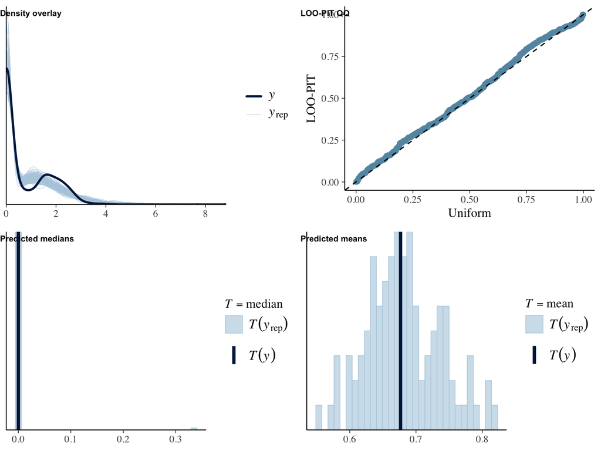

```
 Family: hurdle_gamma
  Links: mu = log; hu = logit
Formula: self_disc ~ 1 + age + male + edu + version
         hu ~ 1 + age + male + edu + version
   Data: object (Number of observations: 558)
  Draws: 4 chains, each with iter = 1000; warmup = 500; thin = 1;
         total post-warmup draws = 2000

Regression Coefficients:
                       Estimate Est.Error l-95% CI u-95% CI Rhat Bulk_ESS Tail_ESS
Intercept                  0.62      0.16     0.31     0.94 1.00     2339     1703
hu_Intercept               1.06      0.38     0.34     1.83 1.00     2583     1052
age                       -0.00      0.00    -0.01     0.00 1.00     2301     1681
male                       0.01      0.08    -0.14     0.16 1.00     2589     1496
edu                       -0.02      0.05    -0.10     0.07 1.00     2436     1708
versionLike               -0.06      0.09    -0.24     0.11 1.00     1707     1559
versionLike&dislike       -0.11      0.10    -0.29     0.09 1.00     1696     1542
hu_age                    -0.01      0.01    -0.02     0.00 1.00     4108     1513
hu_male                   -0.07      0.18    -0.40     0.28 1.00     2528     1701
hu_edu                    -0.21      0.10    -0.41    -0.01 1.00     1876     1667
hu_versionLike             0.02      0.21    -0.39     0.42 1.00     1732     1417
hu_versionLike&dislike     0.24      0.21    -0.19     0.67 1.00     1868     1385

Further Distributional Parameters:
      Estimate Est.Error l-95% CI u-95% CI Rhat Bulk_ESS Tail_ESS
shape     3.15      0.28     2.63     3.72 1.00     2396     1441

Draws were sampled using sampling(NUTS). For each parameter, Bulk_ESS
and Tail_ESS are effective sample size measures, and Rhat is the potential
scale reduction factor on split chains (at convergence, Rhat = 1).
```

```
Results of marginal effects:
    Outcome    term                 contrast estimate conf.low conf.high
1 self_disc     age                    dY/dX  0.00247 -0.00334   0.00788
2 self_disc     edu                    dY/dX  0.06876 -0.02430   0.16068
3 self_disc    male                    1 - 0  0.03106 -0.12558   0.21078
4 self_disc version Like & dislike - Control -0.16190 -0.37120   0.03283
5 self_disc version           Like - Control -0.05431 -0.27058   0.16002
```

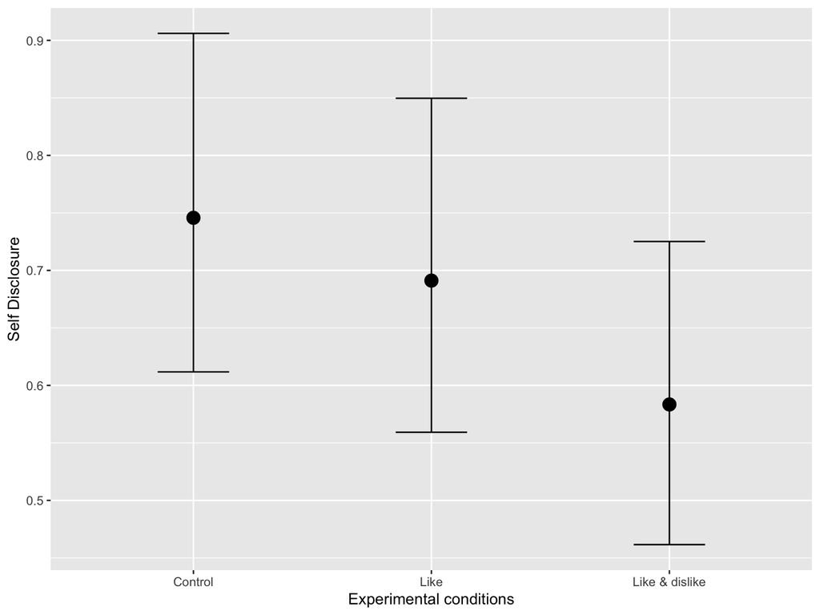

```r
   run_hurdles(object = d, name = "self_disc_ctrl", outcome = "self_disc",
               predictor = "version", y_lab = "Self Disclosure", x_lab = "Experimental conditions")
```

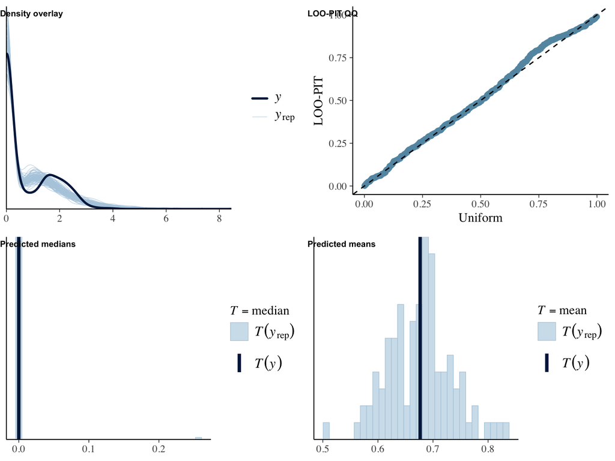

```
 Family: hurdle_gamma
  Links: mu = log; hu = logit
Formula: self_disc ~ 1 + age + male + edu + version_lkdslk
         hu ~ 1 + age + male + edu + version_lkdslk
   Data: object (Number of observations: 558)
  Draws: 4 chains, each with iter = 1000; warmup = 500; thin = 1;
         total post-warmup draws = 2000

Regression Coefficients:
                         Estimate Est.Error l-95% CI u-95% CI Rhat Bulk_ESS Tail_ESS
Intercept                    0.53      0.17     0.19     0.87 1.00     2479     1859
hu_Intercept                 1.29      0.36     0.57     1.98 1.00     2404     1410
age                         -0.00      0.00    -0.01     0.00 1.00     2425     1401
male                         0.01      0.08    -0.14     0.17 1.00     1956     1567
edu                         -0.02      0.05    -0.11     0.07 1.00     2488     1633
version_lkdslkLike           0.04      0.09    -0.14     0.22 1.00     1938     1586
version_lkdslkControl        0.10      0.10    -0.10     0.29 1.00     1854     1807
hu_age                      -0.01      0.01    -0.02     0.00 1.00     4250     1543
hu_male                     -0.06      0.18    -0.41     0.32 1.00     2280     1342
hu_edu                      -0.20      0.10    -0.41     0.01 1.00     2800     1522
hu_version_lkdslkLike       -0.21      0.22    -0.66     0.21 1.00     1427     1307
hu_version_lkdslkControl    -0.24      0.22    -0.67     0.19 1.00     1506     1450

Further Distributional Parameters:
      Estimate Est.Error l-95% CI u-95% CI Rhat Bulk_ESS Tail_ESS
shape     3.15      0.28     2.61     3.71 1.00     1843     1401

Draws were sampled using sampling(NUTS). For each parameter, Bulk_ESS
and Tail_ESS are effective sample size measures, and Rhat is the potential
scale reduction factor on split chains (at convergence, Rhat = 1).
```

```
Results of marginal effects:
    Outcome           term                 contrast estimate conf.low conf.high
1 self_disc            age                    dY/dX  0.00229 -0.00315   0.00766
2 self_disc            edu                    dY/dX  0.06591 -0.02773   0.16200
3 self_disc           male                    1 - 0  0.03524 -0.14566   0.21115
4 self_disc version_lkdslk Control - Like & dislike  0.16275 -0.04527   0.36627
5 self_disc version_lkdslk    Like - Like & dislike  0.10805 -0.09466   0.30697
```

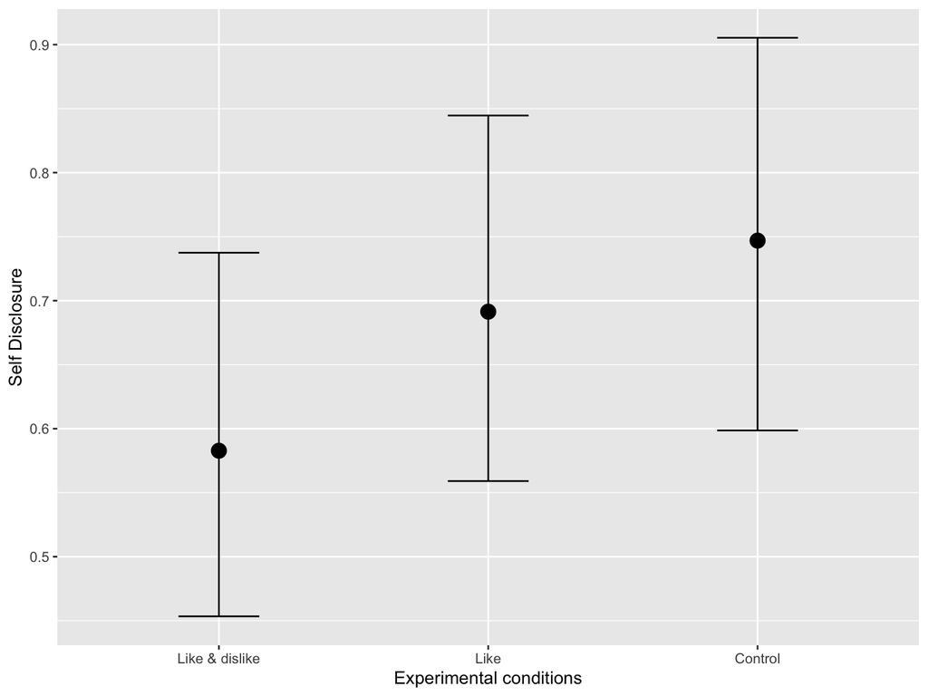

```r
   run_hurdles(object = d, name = "self_disc_lkdslk", outcome = "self_disc",
               predictor = "version_lkdslk", y_lab = "Self Disclosure", x_lab = "Experimental conditions")
```

#### Privacy Concerns

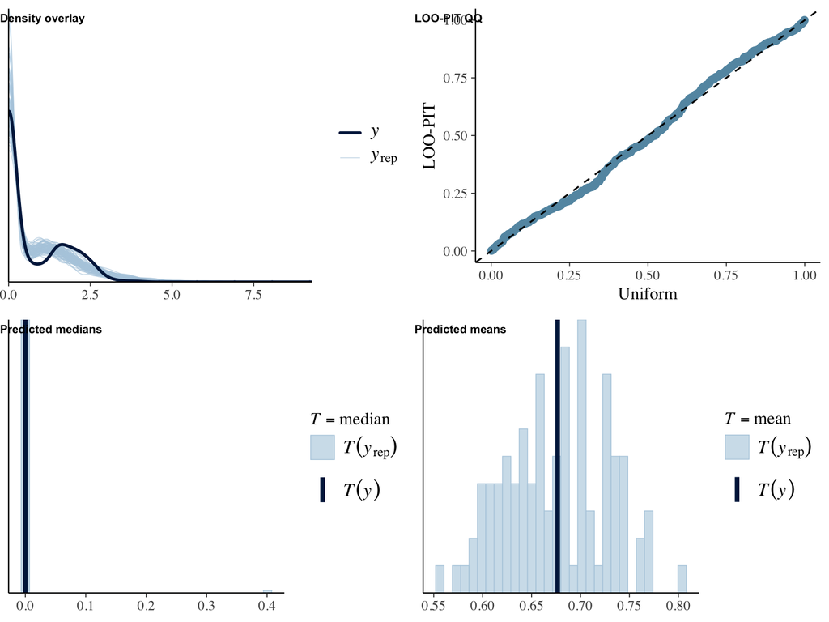

```
 Family: hurdle_gamma
  Links: mu = log; hu = logit
Formula: self_disc ~ 1 + age + male + edu + pri_con_fs
         hu ~ 1 + age + male + edu + pri_con_fs
   Data: object (Number of observations: 558)
  Draws: 4 chains, each with iter = 1000; warmup = 500; thin = 1;
         total post-warmup draws = 2000

Regression Coefficients:
              Estimate Est.Error l-95% CI u-95% CI Rhat Bulk_ESS Tail_ESS
Intercept         0.62      0.17     0.28     0.95 1.00     2685     1707
hu_Intercept      0.54      0.39    -0.19     1.32 1.01     3082     1653
age              -0.00      0.00    -0.01     0.00 1.00     2246     1386
male              0.02      0.08    -0.13     0.17 1.00     2096     1491
edu              -0.02      0.05    -0.11     0.07 1.00     3068     1639
pri_con_fs       -0.02      0.03    -0.07     0.04 1.00     2657     1592
hu_age           -0.01      0.01    -0.02     0.00 1.00     4230     1435
hu_male          -0.04      0.18    -0.38     0.31 1.00     2122     1570
hu_edu           -0.23      0.10    -0.43    -0.03 1.00     2303     1571
hu_pri_con_fs     0.19      0.06     0.07     0.30 1.00     2459     1405

Further Distributional Parameters:
      Estimate Est.Error l-95% CI u-95% CI Rhat Bulk_ESS Tail_ESS
shape     3.14      0.27     2.65     3.70 1.00     1905     1381

Draws were sampled using sampling(NUTS). For each parameter, Bulk_ESS
and Tail_ESS are effective sample size measures, and Rhat is the potential
scale reduction factor on split chains (at convergence, Rhat = 1).
```

```
Results of marginal effects:
    Outcome       term contrast estimate conf.low conf.high
1 self_disc        age    dY/dX  0.00215 -0.00317   0.00749
2 self_disc        edu    dY/dX  0.07362 -0.02399   0.17138
3 self_disc       male    1 - 0  0.02507 -0.14058   0.19214
4 self_disc pri_con_fs    dY/dX -0.08240 -0.13518  -0.02711
```

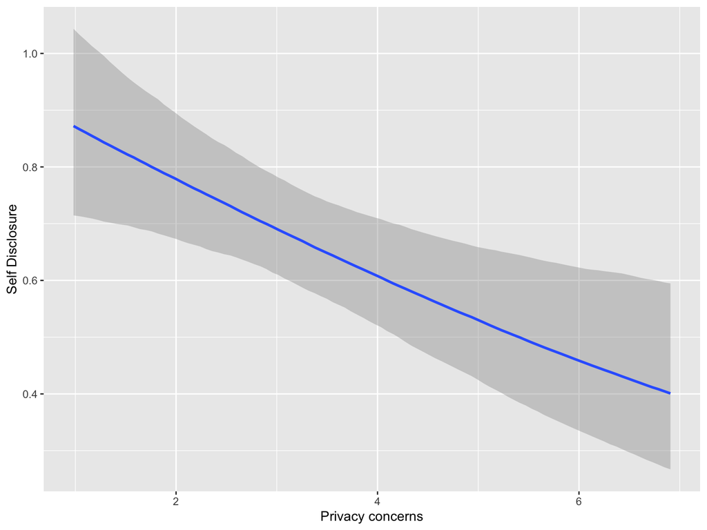

```r
run_hurdles(
  object = d,
  name = "self_disc_pricon",
  outcome = "self_disc",
  predictor = "pri_con_fs",
  y_lab = "Self Disclosure",
  x_lab = "Privacy concerns"
  )
```

Let’s explore how number of communicated words differ for people very much concerned versus not concerned at all.

```r
# let's extract effects for 1
self_disc_pricon_1 <-
  fig_self_disc_pricon$data %>%
  filter(pri_con_fs == min(pri_con_fs)) %>%
  pull(estimate__) %>%
  round(0)

# let's extract effects for 7
self_dics_pricon_7 <-
  fig_self_disc_pricon$data %>%
  filter(pri_con_fs == max(pri_con_fs)) %>%
  pull(estimate__) %>%
  round(0)
```

#### Gratifications General

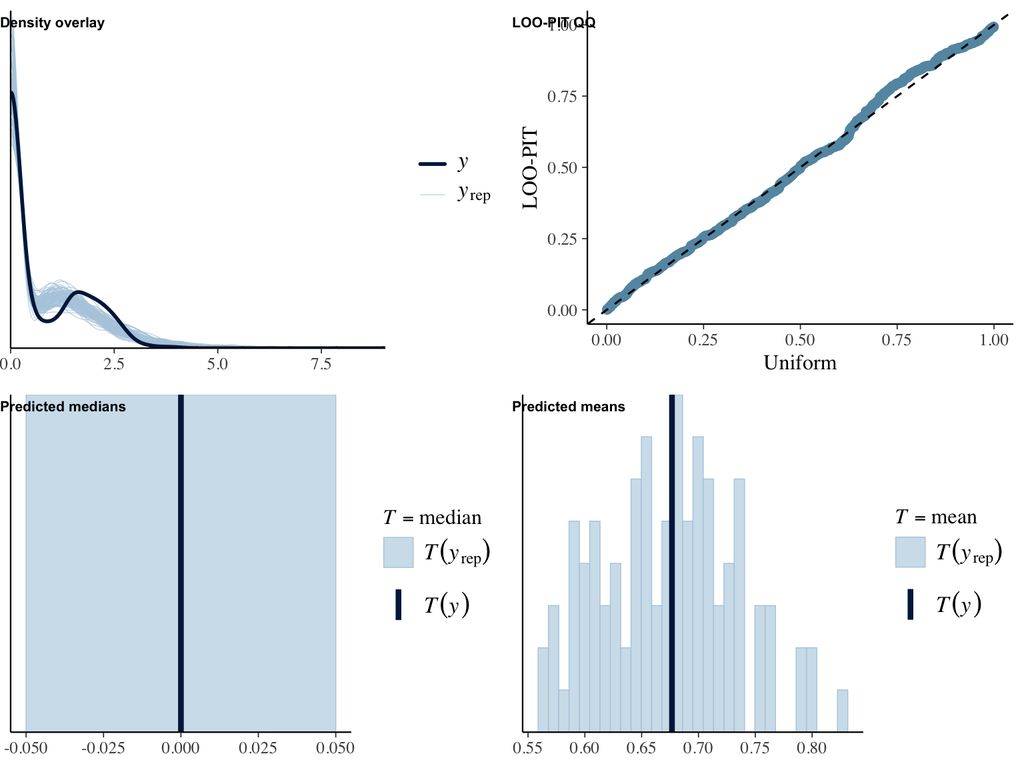

```
 Family: hurdle_gamma
  Links: mu = log; hu = logit
Formula: self_disc ~ 1 + age + male + edu + grats_gen_fs
         hu ~ 1 + age + male + edu + grats_gen_fs
   Data: object (Number of observations: 558)
  Draws: 4 chains, each with iter = 1000; warmup = 500; thin = 1;
         total post-warmup draws = 2000

Regression Coefficients:
                Estimate Est.Error l-95% CI u-95% CI Rhat Bulk_ESS Tail_ESS
Intercept           0.72      0.24     0.25     1.19 1.00     1982     1717
hu_Intercept        2.27      0.53     1.21     3.32 1.00     2267     1580
age                -0.00      0.00    -0.01     0.00 1.00     2368     1590
male                0.01      0.07    -0.14     0.16 1.00     2331     1565
edu                -0.02      0.05    -0.11     0.07 1.00     2103     1478
grats_gen_fs       -0.03      0.04    -0.10     0.04 1.00     2344     1379
hu_age             -0.01      0.01    -0.02     0.00 1.01     4290     1724
hu_male            -0.09      0.18    -0.45     0.24 1.01     1978     1336
hu_edu             -0.22      0.10    -0.43    -0.02 1.01     2149     1269
hu_grats_gen_fs    -0.23      0.08    -0.39    -0.07 1.00     2082     1536

Further Distributional Parameters:
      Estimate Est.Error l-95% CI u-95% CI Rhat Bulk_ESS Tail_ESS
shape     3.15      0.28     2.63     3.69 1.00     1966     1288

Draws were sampled using sampling(NUTS). For each parameter, Bulk_ESS
and Tail_ESS are effective sample size measures, and Rhat is the potential
scale reduction factor on split chains (at convergence, Rhat = 1).
```

```
Results of marginal effects:
    Outcome         term contrast estimate conf.low conf.high
1 self_disc          age    dY/dX  0.00235 -0.00316   0.00742
2 self_disc          edu    dY/dX  0.06813 -0.03054   0.16486
3 self_disc grats_gen_fs    dY/dX  0.06881 -0.00848   0.14153
4 self_disc         male    1 - 0  0.03999 -0.11453   0.20852
```

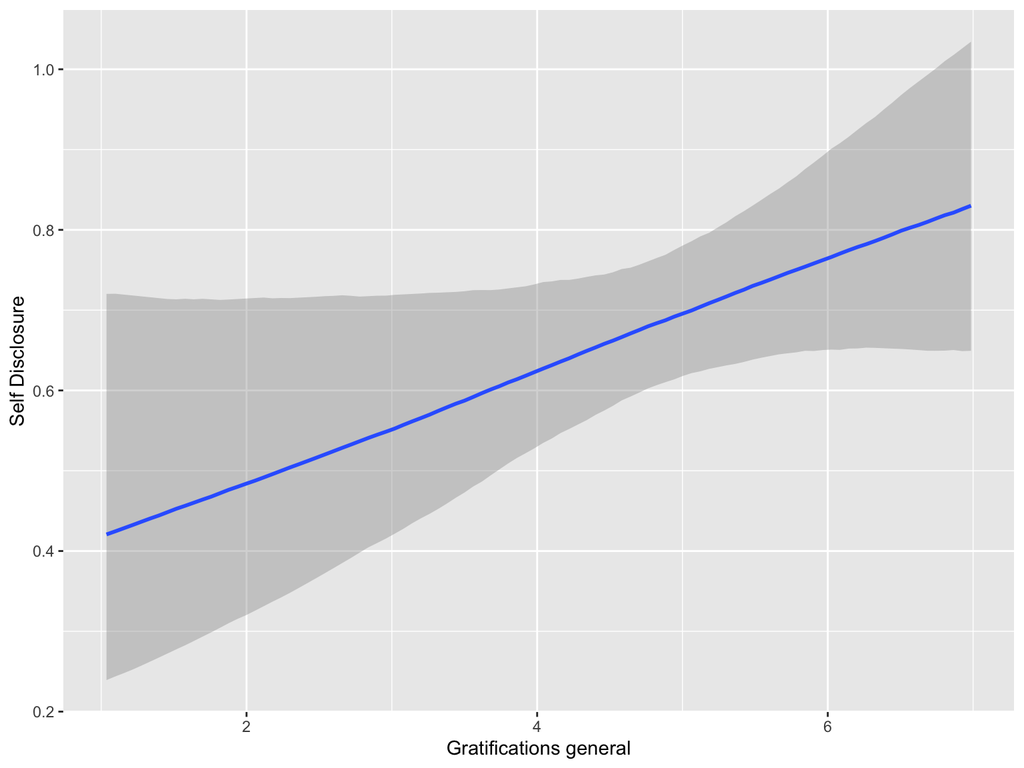

```r
run_hurdles(
  object = d,
  name = "self_disc_grats",
  outcome = "self_disc",
  predictor = "grats_gen_fs",
  y_lab = "Self Disclosure",
  x_lab = "Gratifications general"
  )
```

#### Privacy Deliberation

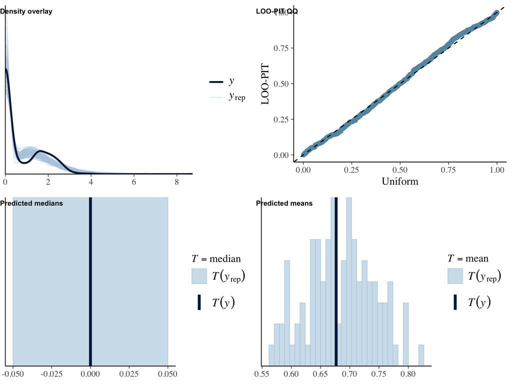

```
 Family: hurdle_gamma
  Links: mu = log; hu = logit
Formula: self_disc ~ 1 + age + male + edu + pri_del_fs
         hu ~ 1 + age + male + edu + pri_del_fs
   Data: object (Number of observations: 558)
  Draws: 4 chains, each with iter = 1000; warmup = 500; thin = 1;
         total post-warmup draws = 2000

Regression Coefficients:
              Estimate Est.Error l-95% CI u-95% CI Rhat Bulk_ESS Tail_ESS
Intercept         0.86      0.22     0.44     1.28 1.00     2723     1753
hu_Intercept     -0.16      0.48    -1.10     0.78 1.00     2941     1715
age              -0.00      0.00    -0.01     0.00 1.00     2188     1593
male              0.00      0.08    -0.14     0.15 1.00     2700     1600
edu              -0.03      0.05    -0.12     0.06 1.00     2755     1386
pri_del_fs       -0.07      0.03    -0.13    -0.01 1.00     2833     1777
hu_age           -0.01      0.01    -0.02     0.01 1.00     4099     1458
hu_male          -0.01      0.17    -0.37     0.32 1.00     2169     1639
hu_edu           -0.22      0.11    -0.42    -0.01 1.00     2362     1380
hu_pri_del_fs     0.30      0.08     0.14     0.47 1.00     2936     1652

Further Distributional Parameters:
      Estimate Est.Error l-95% CI u-95% CI Rhat Bulk_ESS Tail_ESS
shape     3.20      0.28     2.68     3.78 1.00     2292     1473

Draws were sampled using sampling(NUTS). For each parameter, Bulk_ESS
and Tail_ESS are effective sample size measures, and Rhat is the potential
scale reduction factor on split chains (at convergence, Rhat = 1).
```

```
Results of marginal effects:
    Outcome       term contrast estimate conf.low conf.high
1 self_disc        age    dY/dX  0.00121 -0.00417   0.00629
2 self_disc        edu    dY/dX  0.06299 -0.03655   0.16104
3 self_disc       male    1 - 0  0.00731 -0.15851   0.17150
4 self_disc pri_del_fs    dY/dX -0.16049 -0.23907  -0.08714
```

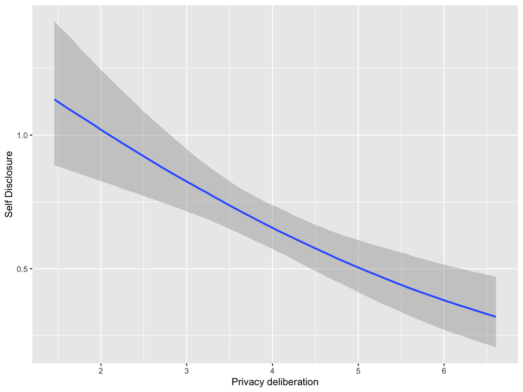

```r
run_hurdles(
  object = d,
  name = "self_disc_pridel",
  outcome = "self_disc",
  predictor = "pri_del_fs",
  y_lab = "Self Disclosure",
  x_lab = "Privacy deliberation"
  )
```

#### Trust General

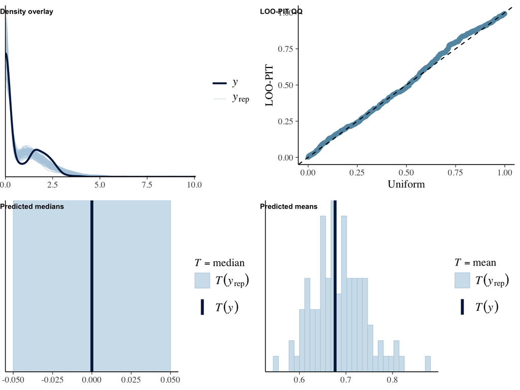

```
 Family: hurdle_gamma
  Links: mu = log; hu = logit
Formula: self_disc ~ 1 + age + male + edu + trust_gen_fs
         hu ~ 1 + age + male + edu + trust_gen_fs
   Data: object (Number of observations: 558)
  Draws: 4 chains, each with iter = 1000; warmup = 500; thin = 1;
         total post-warmup draws = 2000

Regression Coefficients:
                Estimate Est.Error l-95% CI u-95% CI Rhat Bulk_ESS Tail_ESS
Intercept           0.48      0.29    -0.10     1.03 1.00     2904     1898
hu_Intercept        3.10      0.64     1.90     4.35 1.00     2988     1728
age                -0.00      0.00    -0.01     0.00 1.00     2313     1364
male                0.02      0.08    -0.13     0.18 1.00     2340     1292
edu                -0.02      0.05    -0.11     0.07 1.00     2853     1747
trust_gen_fs        0.02      0.04    -0.07     0.10 1.00     3237     1488
hu_age             -0.01      0.01    -0.02     0.00 1.00     4057     1258
hu_male            -0.08      0.18    -0.43     0.28 1.00     2640     1596
hu_edu             -0.21      0.10    -0.42    -0.00 1.00     2657     1781
hu_trust_gen_fs    -0.36      0.10    -0.55    -0.17 1.00     3105     1645

Further Distributional Parameters:
      Estimate Est.Error l-95% CI u-95% CI Rhat Bulk_ESS Tail_ESS
shape     3.14      0.28     2.63     3.72 1.00     2453     1317

Draws were sampled using sampling(NUTS). For each parameter, Bulk_ESS
and Tail_ESS are effective sample size measures, and Rhat is the potential
scale reduction factor on split chains (at convergence, Rhat = 1).
```

```
Results of marginal effects:
    Outcome         term contrast estimate conf.low conf.high
1 self_disc          age    dY/dX  0.00297  -0.0024   0.00838
2 self_disc          edu    dY/dX  0.06650  -0.0330   0.16987
3 self_disc         male    1 - 0  0.04613  -0.1255   0.21384
4 self_disc trust_gen_fs    dY/dX  0.14512   0.0566   0.23565
```

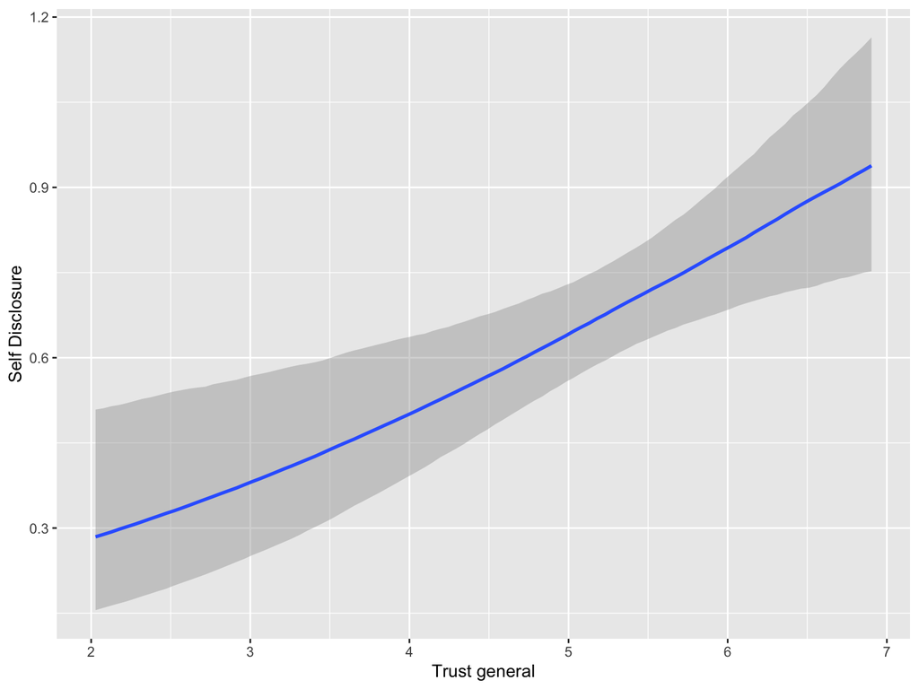

```r
run_hurdles(
  object = d,
  name = "self_disc_trust",
  outcome = "self_disc",
  predictor = "trust_gen_fs",
  y_lab = "Self Disclosure",
  x_lab = "Trust general"
  )
```